# Math 189: Resampling I

# Outline

- In previous lectures we introduced least squares method for linear regression.
- Now we introduce some resampling methods and their applications in statistical learning.

## Resampling Method

- The *resampling method* is an indispensable tool in modern statistics.
- Resampling involves repeatedly drawing samples from a training set, and refitting a model of interest on each sample in order to obtain additional information about the fitted model.
- Resampling is widely used in many statistical studies:
1. Performance evaluation.
2. Hyper-parameter selection.
3. Inference for estimated parameters.
4. Hypothesis testing.
5. Model validation.

# Question 1: How to Evaluate a Statistical Model?

“All models are wrong, but some are useful.”

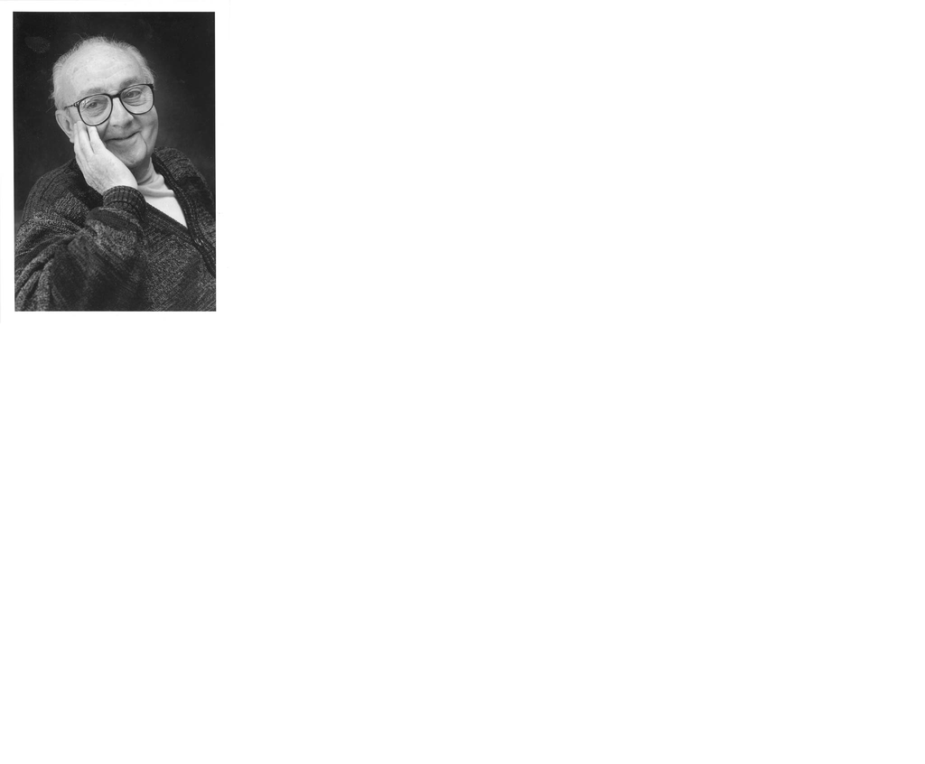

George Box

- All statistical models depend on certain assumptions, and hence are simplifications of reality.
- Some assumptions are imposed, as we do not know the truth and have to “guess”.
- Some simplifications are very useful:
1. Ignore nuisance information.
2. Explain complex phenomena with simple model.
3. Make computation feasible.
- For a statistical problem, we can establish various statistical models based on different assumptions.
- Which model should we use?
- Choose the model that best fits our objective.
- For a given objective, how to assess various models?
- Suppose that we want to choose a model that has the best prediction performance. In other words, the smallest *prediction error*.

## Training Error

- Let’s consider a regression model with only one predictor:
  $$y = f(x) + e,$$
  where $y$ is the response variable and $x$ is the covariate, and $e$ represents the proportion of $y$ that can not be explained by $x$.
- Suppose we observe a sample $\{ x_i, y_i \}$ for $i =1, \ldots, n$. We estimate the unknown function $f(\cdot)$ by some estimator $\widehat{f} (\cdot)$.
- Then $y_i$ will be estimated by $\widehat{f} (x_i)$. The training error is defined as
  $$\frac{1}{n} \sum_{i=1}^n {\left( y_i - \widehat{f} (x_i) \right)}^2$$
  This training error is usually called *mean squared error* (MSE) or *in-sample error*.

## Test Error

- Suppose we observe additional observations, $\{ x_i^{\mbox{test}} \}$ for $i =1, \ldots, m$, for which we want to predict/classify the response.
- We can predict the response variable $y_i^{\mbox{test}}$ corresponding to $x_i^{\mbox{test}}$ as $\widehat{f} (x_i^{\mbox{test}})$. The test error is
  $$\frac{1}{m} \sum_{i=1}^m {\left( y_i^{\mbox{test}} - \widehat{f} (x_i^{\mbox{test}}) \right)}^2$$
- The test error is usually called *mean squared prediction error* (MSPE) or *out-of-sample* error.
- Usually we don’t observe $y_i^{\mbox{test}}$, and hence we can not directly calculate the test error. Hence, we cannot directly select a model that minimizes the test error.
- The model that minimizes the training error may not be the one that minimizes the test error!

# Question 2: How to Select Hyper-parameters

- The terminology *hyper-parameter* is first used in Bayesian statistics to denote the parameter of prior distributions. In Bayes statistical inference, the priors express one’s beliefs about this quantity before any evidence is taken into account.
- Many statistical methods involved some parameters whose values should be set before the learning process. In a general sense, they can also be called hyper-parameters.
- Usually, we need to choose these hyper-parameters before we fit a statistical model.
- Different choices of hyper-parameters lead to different models.
- How do we choose these hyper-parameters?

## Hyper-parameters Selection

- In practice, we want to choose a set of hyper-parameters that lead to a model with certain advantages:
1. Model accuracy
2. Computational efficiency
3. Flexibility
4. Robustness
- For each objective, we need to choose a set of hyper-parameters that minimizes some loss function:
1. Prediction error.
2. Computational cost.
3. Loss when model is mis-specified.
4. Loss when assumptions are violated.

## The Validation Set Approach

- Suppose we want to estimate the test error associated with fitting a particular statistical model on a sample.
- The true test/prediction set usually does not have the information of the response variable or true class labels. (Otherwise no need to predict.)
- We cannot directly assess the test error on the test set.
- The validation set approach involves randomly dividing the available set of observations into two parts, a *training set* and a *validation set*.
- We first fit the model on the training set. The fitted model is then used to predict the responses of the observations in the validation set.
- The resulting validation set error provides an estimate of the test error.

### Normal Learning Process

- Training a statistical model using the observations in the *training set*, and predict the *test set*.
- Problem: Cannot assess the test error because we do not know the true responses of test set.

### The Validation Set Approach

- Training a statistical model using the observations in the *training set*.
- Validate trained model by the “test error” in the *validation set*.
- Use the trained model to predict the *test set*.
- Model accuracy is assessed by the test error in the validation set.
- Select a model/parameter that minimizes the test error in the validation set.

## Example: Predict MPG with Horsepower

- We collected a dataset of 392 observations (automobiles). For each automobile, we record the miles per gallon (MPG) and horsepower.
- We are interested in predicting the MPG of an automobile with its horsepower:
  $$\mbox{MPG} = f(\mbox{horsepower}) + \mbox{error},$$
  where $f$ is some regression function.
- Which model gives the best prediction performance?

### Five Candidate Models

- Let $y$ be MPG and $x$ be horsepower.
- We consider fitting the model where $f (\cdot)$ is a polynomial of order from 1 to 5:
  $$\begin{align*}
  \mbox{Model 1}: & y = a_0 + a_1 x + \epsilon \\
  \mbox{Model 2}: & y = a_0 + a_1 x + a_2 x^2 + \epsilon \\
  \mbox{Model 3}: & y = a_0 + a_1 x + a_2 x^2 + a_3 x^3 + \epsilon \\
  \mbox{Model 4}: & y = a_0 + a_1 x + a_2 x^2 + a_3 x^3 + a_4 x^4 + \epsilon \\
  \mbox{Model 5}: & y = a_0 + a_1 x + a_2 x^2 + a_3 x^3 + a_4 x^4 + a_5 x^5 \epsilon
  \end{align*}$$
  Goal: compare the model that minimizes the training error and the model that minimizes the test error.

### Example: Validation Set Approach

- We randomly divide the observed sample $\{ x_i, y_i \}$ for $i =1, \ldots, 392$ into a training set $\{ x_i^t, y_i^t \}$ for $i =1, \ldots, 196$, and a validation set $\{ x_i^v, y_i^v \}$ for $i =1, \ldots, 196$.
- We use the training set to train an estimator $\widehat{f} (\cdot)$. Then $y_i$ is estimated via $\widehat{f} (x_i)$.
- The training error is defined as
  $$\frac{1}{196} \sum_{i=1}^{196} {\left( y_i^t - \widehat{f} (x_i^t) \right)}^2.$$
- The test error is estimated by the prediction error of the validation set
  $$\frac{1}{196} \sum_{i=1}^{196} {\left( y_i^v - \widehat{f} (x_i^v) \right)}^2.$$
- The training error and test error of each model are given in the following table.

```r
library(ISLR)
head(Auto)
```

```
##   mpg cylinders displacement horsepower weight acceleration year origin
## 1  18         8          307        130   3504         12.0   70      1
## 2  15         8          350        165   3693         11.5   70      1
## 3  18         8          318        150   3436         11.0   70      1
## 4  16         8          304        150   3433         12.0   70      1
## 5  17         8          302        140   3449         10.5   70      1
## 6  15         8          429        198   4341         10.0   70      1
##                        name
## 1 chevrolet chevelle malibu
## 2         buick skylark 320
## 3        plymouth satellite
## 4             amc rebel sst
## 5               ford torino
## 6          ford galaxie 500
```

```r
set.seed(777)
train_ind <- sample(392,size=196)
val_ind <- setdiff(seq(1,392),train_ind)
Auto_train <- Auto[train_ind,]
Auto_val <- Auto[val_ind,]

# Train
y <- Auto_train$mpg
x <- Auto_train$horsepower
x2 <- x^2
x3 <- x^3
x4 <- x^4
x5 <- x^5
mdl1 <- lm(y ~ x)
mdl2 <- lm(y ~ x + x2)
mdl3 <- lm(y ~ x + x2 + x3)
mdl4 <- lm(y ~ x + x2 + x3 + x4)
mdl5 <- lm(y ~ x + x2 + x3 + x4 + x5)
train_err <- rep(0,5)
train_err[1] <- mean((y - mdl1$fitted.values)^2)
train_err[2] <- mean((y - mdl2$fitted.values)^2)
train_err[3] <- mean((y - mdl3$fitted.values)^2)
train_err[4] <- mean((y - mdl4$fitted.values)^2)
train_err[5] <- mean((y - mdl5$fitted.values)^2)

# Validate
y <- Auto_val$mpg
x <- Auto_val$horsepower
z1 <- (mdl1$coefficients[1] + mdl1$coefficients[2]*x)
z2 <- (mdl2$coefficients[1] + mdl2$coefficients[2]*x + mdl2$coefficients[3]*x^2)
z3 <- (mdl3$coefficients[1] + mdl3$coefficients[2]*x + mdl3$coefficients[3]*x^2 +
       mdl3$coefficients[4]*x^3)
z4 <- (mdl4$coefficients[1] + mdl4$coefficients[2]*x + mdl4$coefficients[3]*x^2 +
       mdl4$coefficients[4]*x^3 + mdl4$coefficients[5]*x^4)
z5 <- (mdl5$coefficients[1] + mdl5$coefficients[2]*x + mdl5$coefficients[3]*x^2 +
       mdl5$coefficients[4]*x^3 + mdl5$coefficients[5]*x^4 + mdl5$coefficients[6]*x^5)
val_err <- rep(0,5)
val_err[1] <- mean((y - z1)^2)
val_err[2] <- mean((y - z2)^2)
val_err[3] <- mean((y - z3)^2)
val_err[4] <- mean((y - z4)^2)
val_err[5] <- mean((y - z5)^2)

out <- rbind(train_err,val_err)
rownames(out) <- c("Training Error","Validation Error")
colnames(out) <- c("Model 1","Model 2","Model 3","Model 4","Model 5")
out
```

```
##                   Model 1  Model 2  Model 3  Model 4  Model 5
## Training Error   25.16955 18.60159 18.15857 18.12585 18.12438
## Validation Error 23.93545 20.89327 21.72063 22.11040 21.97974
```

- Training error is decreasing in model complexity. (Always true!)
- Validation error may decrease as a function of model complexity up to a point; balance over-fitting (high model order) versus under-fitting (low model order).
- Here, Model 2 has the best validation error.
- The model that minimizes training error (Model 5) is more complicated than the model that minimizes validation error (Model 2).
- This is a common phenomena in statistical learning.

### Repeat Validation

- We can repeat the validation set approach for 10 times and plot the test errors in the following figure.

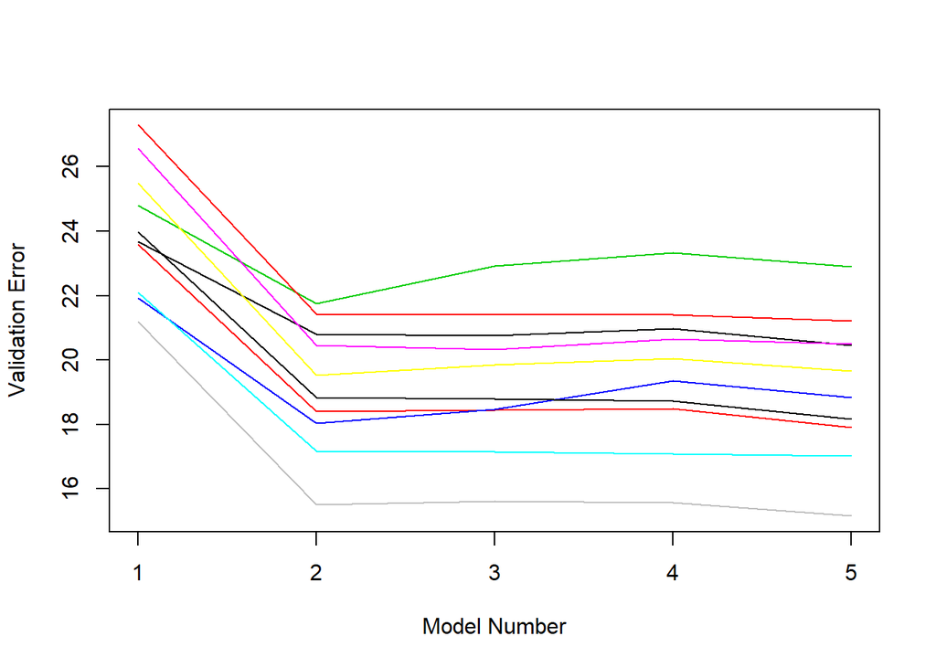

```r
out <- c()
for(count in 1:10)
{

train_ind <- sample(392,size=196)
val_ind <- setdiff(seq(1,392),train_ind)
Auto_train <- Auto[train_ind,]
Auto_val <- Auto[val_ind,]

# Train
y <- Auto_train$mpg
x <- Auto_train$horsepower
x2 <- x^2
x3 <- x^3
x4 <- x^4
x5 <- x^5
mdl1 <- lm(y ~ x)
mdl2 <- lm(y ~ x + x2)
mdl3 <- lm(y ~ x + x2 + x3)
mdl4 <- lm(y ~ x + x2 + x3 + x4)
mdl5 <- lm(y ~ x + x2 + x3 + x4 + x5)
train_err <- rep(0,5)
train_err[1] <- mean((y - mdl1$fitted.values)^2)
train_err[2] <- mean((y - mdl2$fitted.values)^2)
train_err[3] <- mean((y - mdl3$fitted.values)^2)
train_err[4] <- mean((y - mdl4$fitted.values)^2)
train_err[5] <- mean((y - mdl5$fitted.values)^2)

# Validation
y <- Auto_val$mpg
x <- Auto_val$horsepower
z1 <- (mdl1$coefficients[1] + mdl1$coefficients[2]*x)
z2 <- (mdl2$coefficients[1] + mdl2$coefficients[2]*x + mdl2$coefficients[3]*x^2)
z3 <- (mdl3$coefficients[1] + mdl3$coefficients[2]*x + mdl3$coefficients[3]*x^2 +
       mdl3$coefficients[4]*x^3)
z4 <- (mdl4$coefficients[1] + mdl4$coefficients[2]*x + mdl4$coefficients[3]*x^2 +
       mdl4$coefficients[4]*x^3 + mdl4$coefficients[5]*x^4)
z5 <- (mdl5$coefficients[1] + mdl5$coefficients[2]*x + mdl5$coefficients[3]*x^2 +
       mdl5$coefficients[4]*x^3 + mdl5$coefficients[5]*x^4 + mdl5$coefficients[6]*x^5)
val_err <- rep(0,5)
val_err[1] <- mean((y - z1)^2)
val_err[2] <- mean((y - z2)^2)
val_err[3] <- mean((y - z3)^2)
val_err[4] <- mean((y - z4)^2)
val_err[5] <- mean((y - z5)^2)

out <- rbind(out,val_err)
}

plot.ts(t(out),plot.type="single",col=seq(1,10),
        xlab="Model Number",ylab="Validation Error")
```

- The testing error estimated by the validation set approach can be highly variable.
- It depends on the random partition of training and validation sets

## Some Issues with the Validation Set Approach

- The testing error estimated by the validation set approach can be highly variable, depending on precisely which observations are included in the training set and which observations are included in the validation set.
- In the validation set approach, only a subset of the observations, which are included in the training set rather than in the validation set, are used to fit the model.
- Since statistical methods tend to perform worse when trained on fewer observations, this suggests that the validation set error may tend to over-estimate the test error for the model fitted on the entire data set.